# Analysing Twitter for Ubisoft

## 8.1.5 Bootstrap confidence intervals

### a/b.) Generate a bootsrap distribution

A bootstrap assumes that the population is an infinitely large repetition of the sample and may be produces with respect to follower counts by resampling with replacement/repetition and plotted using the `ggplot2` library as deomonstrated in listings *btpop* and *btgg* and shown in figure *btpopfg*.

This shows that the population follower counts is a non-normal skew-right distribution, which is expected because the number of friends is an integer value bound by zero cite:nist2013.

Bootstrapping a population from the sample.

```r
## Resample the Data
(bt_pop <- sample(x, size = 10^6, replace = TRUE)) %>% head()

## > [1]   7 515 262 309 186 166
```

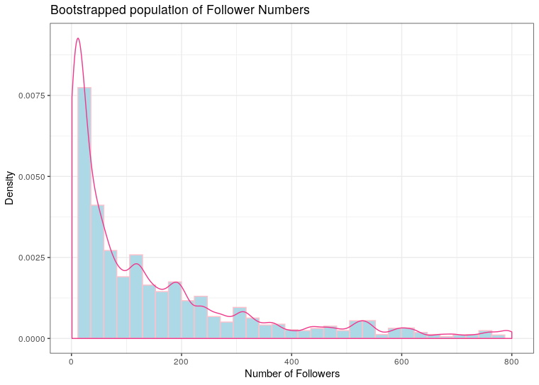

Histogram of the bootrapped population of follower counts

```r
## Make the Population
bt_pop_data <- tibble("Followers" = bt_pop)
ggplot(data = bt_pop_data, aes(x = Followers)) +
  geom_histogram(aes(y = ..density..), fill = "lightblue", bins = 35, col = "pink") +
  geom_density(col = "violetred2") +
  scale_x_continuous(limits = c(1, 800)) +
  theme_bw() +
  labs(x = "Number of Followers", y = "Density",
       title = "Bootstrapped population of Follower Numbers")
```

### c.) Estimate a Confidence Interval for the population mean Follower Counts

In order to perform a bootrap for the population mean value of follower counts it is necessary to:

1. Resample the data with replacement
   - i.e. randomly select values from the sample allowing for repetition
2. Measure the statistic of concern
3. Replicate this a sufficient number of times
   - i.e. Greater than or equal to 1000 times Ch. 5

This is equivalent to drawing a sample from a population that is infinitely large and constructed of repetitions of the sample. This can be performed in *R* as shown in listing *bt1s*.

Confidence Interval of Mean Follower Count in Population

```r
xbar_boot_loop <- replicate(10^3, {
  s <- sample(x, replace = TRUE)
  mean(s)
  })
quantile(xbar_boot_loop, c((1-0.97)/2, (1+0.97)/2))

##       1.5%      98.5%
##   588.4189 10228.7352
```

A 97% probability interval is such that a sample drawn from a population will contain the population mean in that interval 97% of the time, this means that it may be concluded with a high degree of certainty that the true population mean lies between 588 and 10228.

1. Alternative Approaches

   If this data was normally distributed it may have been appropriate to consider bootstrapping the standard error and using a $t$ distribution, however it is more appropriate to use a percentile interval for skewed data such as this, in saying that however this method is not considered to be very accurate in the literature and is often too narrow. Section 4.1
   - It's worth noting that the normal $t$ value bootstrap offers no advantage over using a $t$ distribution (other than being illustrative of bootstrapping generally) Section 4.1

     The `boot` package is a bootstrapping library common among authors in the data science sphere p. 295 p. 237 that implements confidence intervals consistent with work by Davison and Hinkley cite:ripley2020 in there texbook *Bootstrap Methods and their Application*. In this work it is provided that the $BC_{a}$ method of constructing confidence intervals is superior to mere percentile methods in terms of accuracy Ch. 5, a sentiment echoed in the literature. Ch. 5